# Practical Machine Learning- Course Project Writeup

For this assignment the goal is to build a classifier for 5 different ways individuals perform barbell lifts. A correct lift is coded as class {A} while four other incorrect type of lifts are classified as {B, C, D, E}. A variety of measurements were taken from accelerometers on the belt, forearm, and arm of subjects. These measurements constitute the features (predictors) of the model.

I attempted to fit a Support Vector Machine with Radial Basis Kernel using the caret package.

```r
#load packages
require(caret);require(lattice);require(ggplot2);require(kernlab);require(corrplot)
# load data
raw.data<-read.csv('pml-training.csv')
```

Prior to calibrating the model some a priori feature selection was done. Firstly, user identifier was eliminated. The assumption is that with feedback about correct/incorrect performance of the task the individual performing the task can learn and modify his/her behaviour. Our model will not capture this dynamic which would deteriorate the accuracy in the presence of behavioural change. Secondly, higher frequency measurements were omitted and only data post lift is retained. This means the model can classify the lift as correct or any of the four other categories only after the lift is complete. This modeling choice reduced the number of observations and features considerably.

```r
# list of features retained for model calibration
my.features<-c('roll_belt','pitch_belt','yaw_belt','total_accel_belt','gyros_belt_x',
               'gyros_belt_y','gyros_belt_z','accel_belt_x','accel_belt_y','accel_belt_z',
               'magnet_belt_x','magnet_belt_y','magnet_belt_z','roll_arm','pitch_arm',
               'yaw_arm','total_accel_arm','gyros_arm_x','gyros_arm_y','gyros_arm_z',
               'accel_arm_x','accel_arm_y','accel_arm_z','magnet_arm_x','magnet_arm_y',
               'magnet_arm_z','roll_dumbbell','pitch_dumbbell','yaw_dumbbell',
               'total_accel_dumbbell','gyros_dumbbell_x','gyros_dumbbell_y','gyros_dumbbell_z',
               'accel_dumbbell_x','accel_dumbbell_y','accel_dumbbell_z','magnet_dumbbell_x',
               'magnet_dumbbell_y','magnet_dumbbell_z','roll_forearm','pitch_forearm',
               'yaw_forearm','total_accel_forearm','gyros_forearm_x','gyros_forearm_y',
               'gyros_forearm_z','accel_forearm_x','accel_forearm_y','accel_forearm_z',
               'magnet_forearm_x','magnet_forearm_y','magnet_forearm_z')


all.data<-raw.data[,c(my.features,"classe")] # extract the features and class from data frame
set.seed(1981) # set seed for replication
inTrain<-createDataPartition(raw.data$classe, p =.70, list=FALSE) # partition data
```

For computational reasons it is recommended that the **train** function call should be used with matrix rather than formula expression. Therefore, below I split the data into feature and class matrices.

```r
training.features<-all.data[inTrain,my.features] # training features
testing.features<-all.data[-inTrain,my.features] # testing features
training.class<-all.data[inTrain,'classe'] # training class
testing.class<-all.data[-inTrain,'classe'] # testing class
```

Looking at the distribution of the classes we can see that there is no class imbalance and therefore the goal of accuracy maximization should be sufficient. If there was class imbalance alternative optimization criteria would be required.

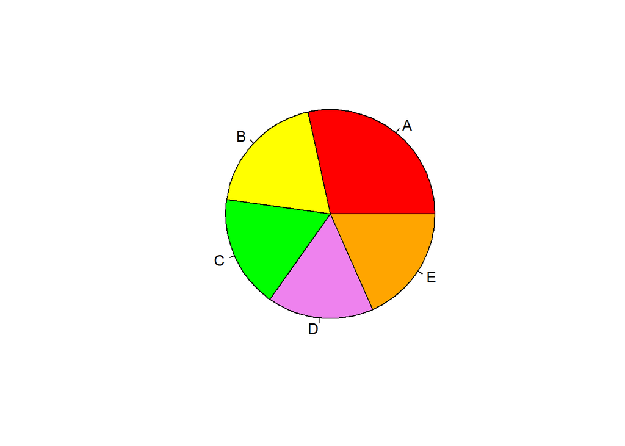

```r
colours = c("red", "yellow", "green", "violet", "orange")
pie(table(training.class), col=colours) # generate a pie chart
```

All the features potentially contain information for the classification task. None of the predictors’ variance is near zero as can be seen in the below table:

```r
nearZeroVar(training.features,  saveMetrics = TRUE)
```

```
##                      freqRatio percentUnique zeroVar   nzv
## roll_belt             1.080495     7.9784524   FALSE FALSE
## pitch_belt            1.029197    12.2443037   FALSE FALSE
## yaw_belt              1.088571    12.9285870   FALSE FALSE
## total_accel_belt      1.057935     0.2111087   FALSE FALSE
## gyros_belt_x          1.059783     0.9172308   FALSE FALSE
## gyros_belt_y          1.161347     0.4950135   FALSE FALSE
## gyros_belt_z          1.063778     1.1647376   FALSE FALSE
## accel_belt_x          1.035514     1.1574580   FALSE FALSE
## accel_belt_y          1.100372     1.0118658   FALSE FALSE
## accel_belt_z          1.116279     2.1038072   FALSE FALSE
## magnet_belt_x         1.083665     2.1693237   FALSE FALSE
## magnet_belt_y         1.117914     2.1110868   FALSE FALSE
## magnet_belt_z         1.008902     3.1811895   FALSE FALSE
## roll_arm             52.711111    17.4783432   FALSE FALSE
## pitch_arm            81.827586    20.2300357   FALSE FALSE
## yaw_arm              32.944444    19.1016961   FALSE FALSE
## total_accel_arm       1.035032     0.4731746   FALSE FALSE
## gyros_arm_x           1.087464     4.6225522   FALSE FALSE
## gyros_arm_y           1.454545     2.6788964   FALSE FALSE
## gyros_arm_z           1.103641     1.7252675   FALSE FALSE
## accel_arm_x           1.034783     5.5907403   FALSE FALSE
## accel_arm_y           1.111842     3.8509136   FALSE FALSE
## accel_arm_z           1.045455     5.5689015   FALSE FALSE
## magnet_arm_x          1.016393     9.5945257   FALSE FALSE
## magnet_arm_y          1.058824     6.2167868   FALSE FALSE
## magnet_arm_z          1.013333     9.1286307   FALSE FALSE
## roll_dumbbell         1.096386    86.9986169   FALSE FALSE
## pitch_dumbbell        2.395604    84.6909806   FALSE FALSE
## yaw_dumbbell          1.109756    86.2924947   FALSE FALSE
## total_accel_dumbbell  1.048421     0.3057436   FALSE FALSE
## gyros_dumbbell_x      1.034803     1.6961491   FALSE FALSE
## gyros_dumbbell_y      1.286747     1.9509354   FALSE FALSE
## gyros_dumbbell_z      1.025822     1.4340831   FALSE FALSE
## accel_dumbbell_x      1.039130     2.9773604   FALSE FALSE
## accel_dumbbell_y      1.159236     3.3195021   FALSE FALSE
## accel_dumbbell_z      1.125749     2.8900051   FALSE FALSE
## magnet_dumbbell_x     1.040323     7.7527845   FALSE FALSE
## magnet_dumbbell_y     1.181818     5.9474412   FALSE FALSE
## magnet_dumbbell_z     1.031250     4.7681444   FALSE FALSE
## roll_forearm         11.359504    13.6638276   FALSE FALSE
## pitch_forearm        67.048780    19.2108903   FALSE FALSE
## yaw_forearm          14.934783    12.8048337   FALSE FALSE
## total_accel_forearm   1.151515     0.5022931   FALSE FALSE
## gyros_forearm_x       1.010695     2.0746888   FALSE FALSE
## gyros_forearm_y       1.058594     5.2558783   FALSE FALSE
## gyros_forearm_z       1.195122     2.1402053   FALSE FALSE
## accel_forearm_x       1.032787     5.6271384   FALSE FALSE
## accel_forearm_y       1.040541     7.1194584   FALSE FALSE
## accel_forearm_z       1.161616     4.0911407   FALSE FALSE
## magnet_forearm_x      1.264151    10.5772731   FALSE FALSE
## magnet_forearm_y      1.049180    13.2925675   FALSE FALSE
## magnet_forearm_z      1.000000    11.7711291   FALSE FALSE
```

Some features do exhibit high correlation but few enough that it was decided best to forego any dimension reduction techniques such as PCA. SVM with Radial Basis Kernel is flexible enough to deal with correlated features to make class distinctions and at the same time PCA computation is unlikely to reduce computational cost of the cost function minimization in the SVM algorithm.

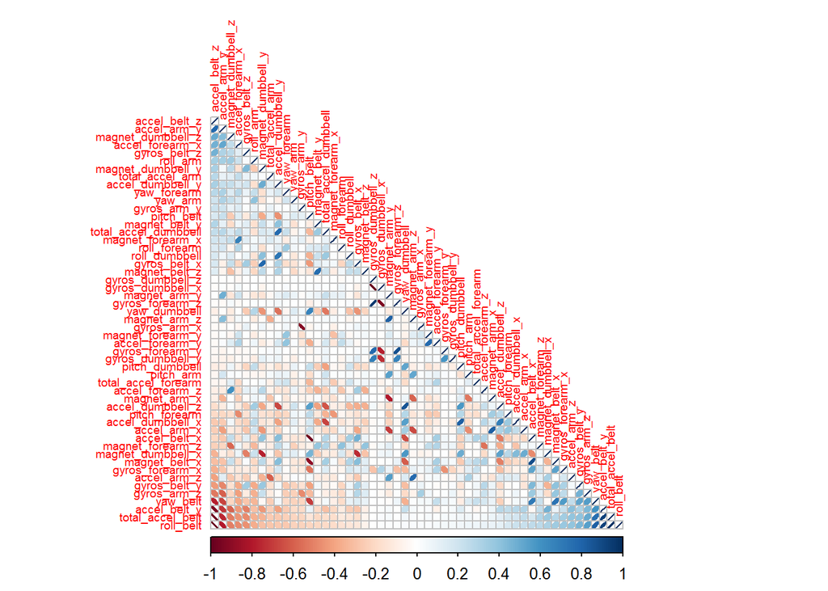

```r
# visualisation of the correlation matrix.
cor <- cor(training.features, use="pairwise", method="pearson") # calculate pairwise correlation
ord <- order(cor[1,]);cor <- cor[ord, ord] # sort the correlation matrix
corrplot(cor, method = "ellipse", type = "lower",tl.cex = .6)
```

It is usual for features to be standardized prior to calibrating SVM. In our case the scale of features is very different so I elect to pre process the features in the call to the **train** function. Below table shows the different scales of the features.

```r
str(training.features)
```

```
## 'data.frame':    13737 obs. of  52 variables:
##  $ roll_belt           : num  1.41 1.42 1.48 1.48 1.45 1.43 1.42 1.42 1.48 1.51 ...
##  $ pitch_belt          : num  8.07 8.07 8.05 8.07 8.17 8.18 8.2 8.21 8.15 8.12 ...
##  $ yaw_belt            : num  -94.4 -94.4 -94.4 -94.4 -94.4 -94.4 -94.4 -94.4 -94.4 -94.4 ...
##  $ total_accel_belt    : int  3 3 3 3 3 3 3 3 3 3 ...
##  $ gyros_belt_x        : num  0.02 0 0.02 0.02 0.03 0.02 0.02 0.02 0 0 ...
##  $ gyros_belt_y        : num  0 0 0 0.02 0 0 0 0 0 0 ...
##  $ gyros_belt_z        : num  -0.02 -0.02 -0.03 -0.02 0 -0.02 0 -0.02 0 -0.02 ...
##  $ accel_belt_x        : int  -22 -20 -22 -21 -21 -22 -22 -22 -21 -21 ...
##  $ accel_belt_y        : int  4 5 3 2 4 2 4 4 4 4 ...
##  $ accel_belt_z        : int  22 23 21 24 22 23 21 21 23 22 ...
##  $ magnet_belt_x       : int  -7 -2 -6 -6 -3 -2 -3 -8 0 -6 ...
##  $ magnet_belt_y       : int  608 600 604 600 609 602 606 598 592 598 ...
##  $ magnet_belt_z       : int  -311 -305 -310 -302 -308 -319 -309 -310 -305 -317 ...
##  $ roll_arm            : num  -128 -128 -128 -128 -128 -128 -128 -128 -129 -129 ...
```

[output cut: 38 more lines]

At this point we are ready to calibrate the SVM model. Due to computational demand we will stick with caret package’s defaults for the tuning parameters. The two tuning parameters for Radial Basis Kernel SVM is the Cost scalar used in the cost function and the Sigma scalar used in the kernel.

```r
# NOTE: model selection takes a very long time
svm.model<-train(x=training.features,
                y=training.class,
                method='svmRadial',
                preProc = c("center", "scale"),
                tuneLength = 10)
# print model output.
svm.model
```

```
## Support Vector Machines with Radial Basis Function Kernel
##
## 13737 samples
##    52 predictor
##     5 classes: 'A', 'B', 'C', 'D', 'E'
##
## Pre-processing: centered, scaled
## Resampling: Bootstrapped (25 reps)
## Summary of sample sizes: 13737, 13737, 13737, 13737, 13737, 13737, ...
## Resampling results across tuning parameters:
##
##   C       Accuracy   Kappa      Accuracy SD  Kappa SD
##     0.25  0.8713296  0.8368428  0.009533117  0.012137784
##     0.50  0.8997460  0.8728754  0.008762106  0.011176735
##     1.00  0.9281404  0.9089250  0.007643617  0.009726249
##     2.00  0.9513432  0.9383585  0.005016657  0.006384186
##     4.00  0.9648972  0.9555443  0.003700874  0.004709101
##     8.00  0.9732627  0.9661528  0.002887239  0.003665890
##    16.00  0.9798114  0.9744499  0.002742228  0.003477402
##    32.00  0.9841220  0.9799092  0.001874022  0.002373806
##    64.00  0.9866369  0.9830933  0.001831221  0.002318312
##   128.00  0.9874847  0.9841667  0.001742016  0.002203809
##
## Tuning parameter 'sigma' was held constant at a value of 0.0141467
## Accuracy was used to select the optimal model using  the largest value.
## The final values used for the model were sigma = 0.0141467 and C = 128.
```

Inspecting the accuracy metric visually versus the cost parameter highlights the fact that increasing C is unlikely to improve the model and that using C=64 is a suitable substitution to 128.

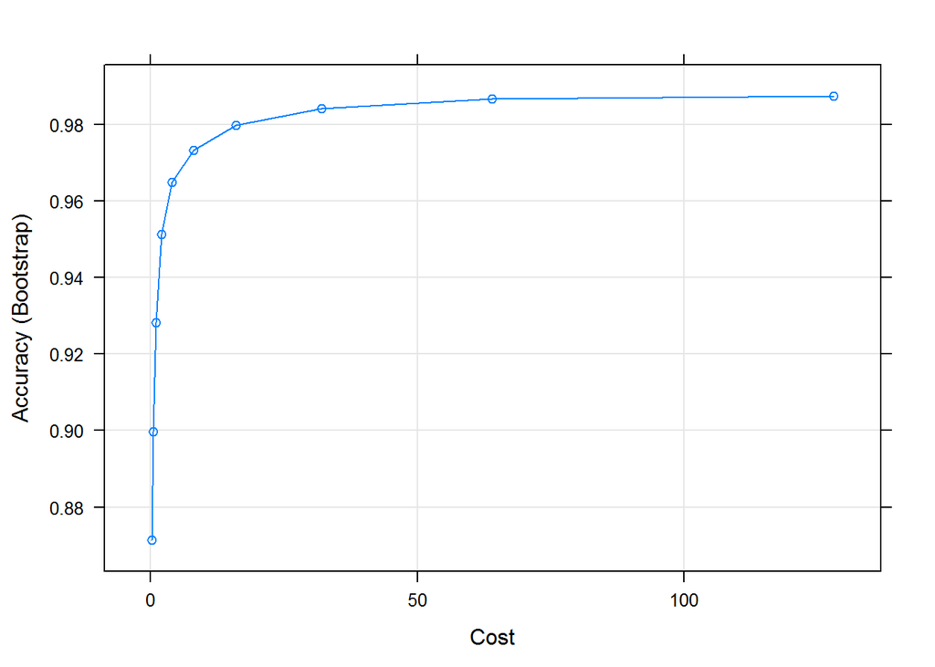

```r
plot(svm.model)
```

With the calibrated model we can now test the accuracy on the testing dataset

```r
my.predictions<-predict(svm.model,testing.features) # generate predictions on the test set
confusionMatrix(my.predictions,testing.class) # create a confusion table
```

```
## Confusion Matrix and Statistics
##
##           Reference
## Prediction    A    B    C    D    E
##          A 1672    6    0    1    0
##          B    2 1130    2    0    0
##          C    0    2 1019   12    1
##          D    0    0    5  948    1
##          E    0    1    0    3 1080
##
## Overall Statistics
##
##                Accuracy : 0.9939
##                  95% CI : (0.9915, 0.9957)
##     No Information Rate : 0.2845
##     P-Value [Acc > NIR] : < 2.2e-16
##
##                   Kappa : 0.9923
##  Mcnemar's Test P-Value : NA
##
## Statistics by Class:
##
##                      Class: A Class: B Class: C Class: D Class: E
## Sensitivity            0.9988   0.9921   0.9932   0.9834   0.9982
## Specificity            0.9983   0.9992   0.9969   0.9988   0.9992
## Pos Pred Value         0.9958   0.9965   0.9855   0.9937   0.9963
## Neg Pred Value         0.9995   0.9981   0.9986   0.9968   0.9996
## Prevalence             0.2845   0.1935   0.1743   0.1638   0.1839
## Detection Rate         0.2841   0.1920   0.1732   0.1611   0.1835
## Detection Prevalence   0.2853   0.1927   0.1757   0.1621   0.1842
## Balanced Accuracy      0.9986   0.9956   0.9950   0.9911   0.9987
```

Finally, we can perform forecasts on the test data of the assignment.

```r
final.validation.data<-read.csv('pml-testing.csv')
final.validation.features<-final.validation.data[,my.features]
validation.predictions<-predict(svm.model,final.validation.features)
# i will omit the final results.  The output matches the test data exactly for all 20 test cases
```

Thank you for reading.